# Practical Machine Learning Project

Emily Stone

24/07/2020

## Background

Six young health participants were asked to perform one set of 10 repetitions of the Unilateral Dumbbell Biceps Curl in five different fashions: exactly according to the specification (Class A), throwing the elbows to the front (Class B), lifting the dumbbell only halfway (Class C), lowering the dumbbell only halfway (Class D) and throwing the hips to the front (Class E).

In this project I Will use data from accelerometers on the belt, forearm, arm, and dumbell of 6 participants, to predict which Class of movements they were performing.

## Looking at data

```r
library(caret)
```

```r
# set the URL for the download
UrlTrain <- "http://d396qusza40orc.cloudfront.net/predmachlearn/pml-training.csv"
UrlTest  <- "http://d396qusza40orc.cloudfront.net/predmachlearn/pml-testing.csv"

# download the datasets
training <- read.csv(url(UrlTrain))
testing  <- read.csv(url(UrlTest))

# create a partition with the training dataset
inTrain  <- createDataPartition(training$classe, p=0.7, list=FALSE)
TrainSet <- training[inTrain, ]
TestSet  <- training[-inTrain, ]
dim(TrainSet)
```

```
## [1] 13737   160
```

- Treatment of NA’s

# remove variables that hold mainly NAs

```r
table(sapply(TrainSet, function(x) sum(is.na(x))))
```

```
##
##     0 13455
##    93    67
```

```r
NAColumns <- sapply(TrainSet, function(x) sum(is.na(x))) >= 13000
TrainSet <- TrainSet[, NAColumns==F]
table(sapply(TrainSet, function(x) sum(is.na(x))))
```

```
##
##  0
## 93
```

# Removing variables that have zero variance:

```r
NZV <- nearZeroVar(TrainSet)
TrainSet <- TrainSet[, -NZV]
dim(TrainSet)
```

```
## [1] 13737    59
```

```r
str(TrainSet)
```

```
## 'data.frame':    13737 obs. of  59 variables:
##  $ X                   : int  3 5 6 8 9 10 11 15 17 19 ...
##  $ user_name           : Factor w/ 6 levels "adelmo","carlitos",..: 2 2 2 2 2 2 2 2 2 2 ...
##  $ raw_timestamp_part_1: int  1323084231 1323084232 1323084232 1323084232 1323084232 1323084232 1323084232 1323084232 1323084232 1323084232 ...
##  $ raw_timestamp_part_2: int  820366 196328 304277 440390 484323 484434 500302 604281 692324 740353 ...
##  $ cvtd_timestamp      : Factor w/ 20 levels "02/12/2011 13:32",..: 9 9 9 9 9 9 9 9 9 9 ...
##  $ num_window          : int  11 12 12 12 12 12 12 12 12 12 ...
##  $ roll_belt           : num  1.42 1.48 1.45 1.42 1.43 1.45 1.45 1.45 1.51 1.57 ...
##  $ pitch_belt          : num  8.07 8.07 8.06 8.13 8.16 8.17 8.18 8.2 8.12 8.06 ...
##  $ yaw_belt            : num  -94.4 -94.4 -94.4 -94.4 -94.4 -94.4 -94.4 -94.4 -94.4 -94.4 ...
##  $ total_accel_belt    : int  3 3 3 3 3 3 3 3 3 3 ...
##  $ gyros_belt_x        : num  0 0.02 0.02 0.02 0.02 0.03 0.03 0 0 0 ...
##  $ gyros_belt_y        : num  0 0.02 0 0 0 0 0 0 0 0 ...
##  $ gyros_belt_z        : num  -0.02 -0.02 -0.02 -0.02 -0.02 0 -0.02 0 -0.02 -0.02 ...
##  $ accel_belt_x        : int  -20 -21 -21 -22 -20 -21 -21 -21 -21 -20 ...
```

[output cut: 45 more lines]

Of the 93 variables, 59 variables have non-zero variance.

# remove identification only variables (columns 1 to 6)

```r
TrainSet <- TrainSet[, -c(1:6)]
dim(TrainSet)
```

```
## [1] 13737    53
```

## Carry out the same transformation for the test data set

```r
TestSet <- TestSet[, NAColumns==F]
TestSet <- TestSet[, -NZV]
TestSet <- TestSet[, -c(1:6)]
dim(TestSet)
```

```
## [1] 5885   53
```

# Prediction models considered

## Classification tree

```r
library(rpart)
library(rattle)
```

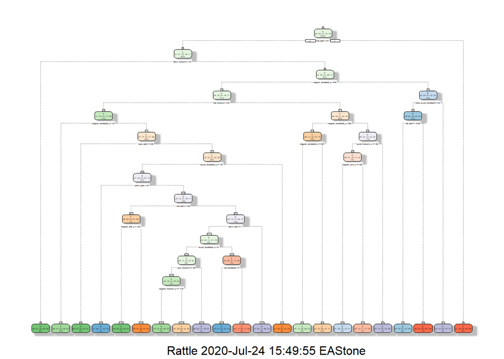

```r
decisionTreeMod1 <- rpart(classe ~ ., data=TrainSet, method="class")
fancyRpartPlot(decisionTreeMod1)
```

```r
predictTreeMod1 <- predict(decisionTreeMod1, TestSet, type = "class")
cmtree <- confusionMatrix(predictTreeMod1, TestSet$classe)
cmtree
```

```
## Confusion Matrix and Statistics
##
##           Reference
## Prediction    A    B    C    D    E
##          A 1521  259   29  117   73
##          B   25  591   75   35   55
##          C   37  140  835  137  104
##          D   59   85   62  603   52
##          E   32   64   25   72  798
##
## Overall Statistics
##
##                Accuracy : 0.7388
##                  95% CI : (0.7274, 0.75)
##     No Information Rate : 0.2845
##     P-Value [Acc > NIR] : < 2.2e-16
##
##                   Kappa : 0.6676
##
##  Mcnemar's Test P-Value : < 2.2e-16
##
## Statistics by Class:
##
##                      Class: A Class: B Class: C Class: D Class: E
## Sensitivity            0.9086   0.5189   0.8138   0.6255   0.7375
## Specificity            0.8865   0.9600   0.9140   0.9476   0.9598
## Pos Pred Value         0.7609   0.7567   0.6664   0.7003   0.8052
## Neg Pred Value         0.9606   0.8926   0.9588   0.9281   0.9420
## Prevalence             0.2845   0.1935   0.1743   0.1638   0.1839
## Detection Rate         0.2585   0.1004   0.1419   0.1025   0.1356
## Detection Prevalence   0.3397   0.1327   0.2129   0.1463   0.1684
## Balanced Accuracy      0.8975   0.7394   0.8639   0.7865   0.8487
```

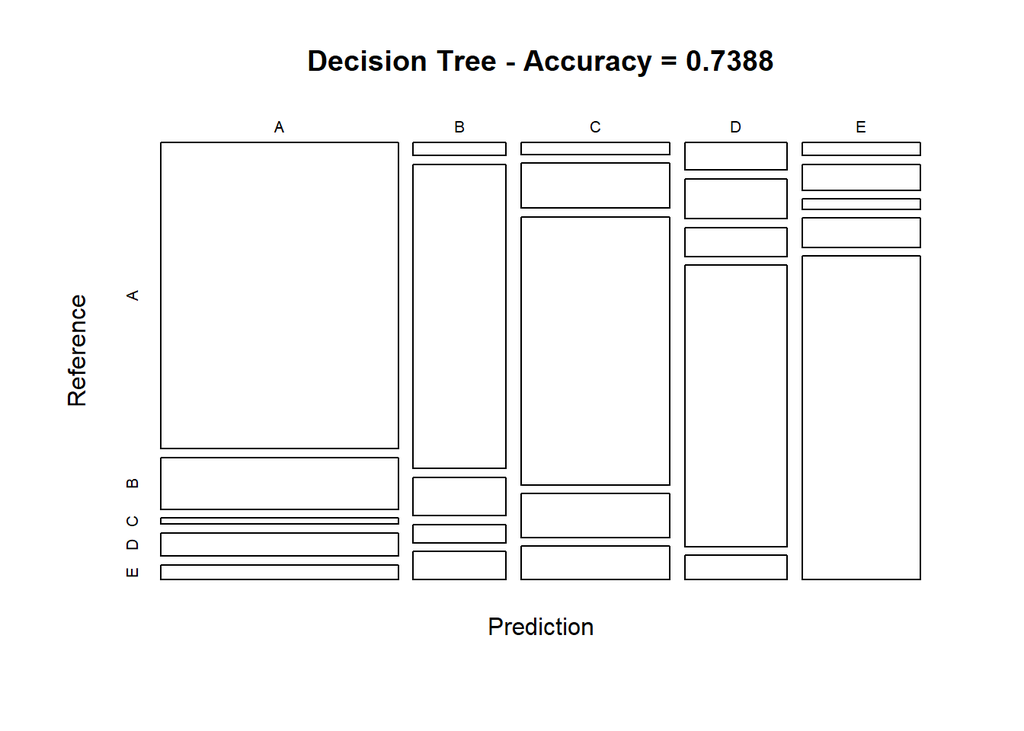

```r
plot(cmtree$table, col = cmtree$byClass,
     main = paste("Decision Tree - Accuracy =", round(cmtree$overall['Accuracy'], 4)))
```

## random forest

```r
controlRF <- trainControl(method="cv", number=3, verboseIter=FALSE)
modRF1 <- train(classe ~ ., data=TrainSet, method="rf", trControl=controlRF)
modRF1$finalModel
```

```
##
## Call:
##  randomForest(x = x, y = y, mtry = param$mtry)
##                Type of random forest: classification
##                      Number of trees: 500
## No. of variables tried at each split: 27
##
##         OOB estimate of  error rate: 0.73%
## Confusion matrix:
##      A    B    C    D    E class.error
## A 3899    4    2    0    1 0.001792115
## B   25 2626    7    0    0 0.012039127
## C    0   11 2375   10    0 0.008764608
## D    1    0   23 2224    4 0.012433393
## E    1    2    4    5 2513 0.004752475
```

```r
predictRF1 <- predict(modRF1, newdata=TestSet)
cmrf <- confusionMatrix(predictRF1, TestSet$classe)
cmrf
```

```
## Confusion Matrix and Statistics
##
##           Reference
## Prediction    A    B    C    D    E
##          A 1672    7    0    0    0
##          B    2 1126    5    2    0
##          C    0    6 1019   17    4
##          D    0    0    2  943    2
##          E    0    0    0    2 1076
##
## Overall Statistics
##
##                Accuracy : 0.9917
##                  95% CI : (0.989, 0.9938)
##     No Information Rate : 0.2845
##     P-Value [Acc > NIR] : < 2.2e-16
##
##                   Kappa : 0.9895
##
##  Mcnemar's Test P-Value : NA
##
## Statistics by Class:
##
##                      Class: A Class: B Class: C Class: D Class: E
## Sensitivity            0.9988   0.9886   0.9932   0.9782   0.9945
## Specificity            0.9983   0.9981   0.9944   0.9992   0.9996
## Pos Pred Value         0.9958   0.9921   0.9742   0.9958   0.9981
## Neg Pred Value         0.9995   0.9973   0.9986   0.9957   0.9988
## Prevalence             0.2845   0.1935   0.1743   0.1638   0.1839
## Detection Rate         0.2841   0.1913   0.1732   0.1602   0.1828
## Detection Prevalence   0.2853   0.1929   0.1777   0.1609   0.1832
## Balanced Accuracy      0.9986   0.9933   0.9938   0.9887   0.9970
```

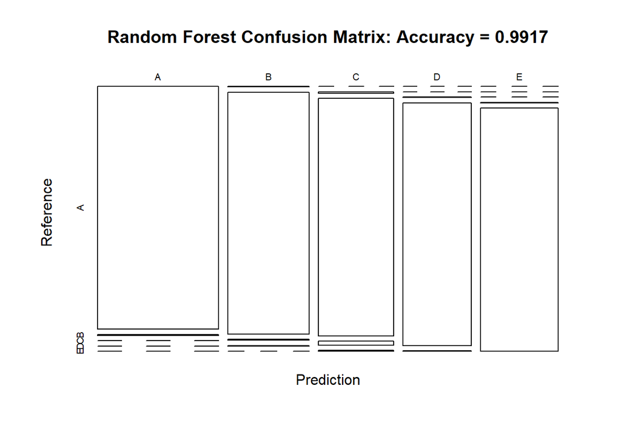

```r
plot(cmrf$table, col = cmrf$byClass, main = paste("Random Forest Confusion Matrix: Accuracy =", round(cmrf$overall['Accuracy'], 4)))
```

## Generalised Boosted Regression Models

```r
set.seed(12345)
controlGBM <- trainControl(method = "repeatedcv", number = 5, repeats = 1)
modGBM  <- train(classe ~ ., data=TrainSet, method = "gbm", trControl = controlGBM, verbose = FALSE)
modGBM$finalModel
```

```
## A gradient boosted model with multinomial loss function.
## 150 iterations were performed.
## There were 52 predictors of which 52 had non-zero influence.
```

```r
predictGBM <- predict(modGBM, newdata=TestSet)
cmGBM <- confusionMatrix(predictGBM, TestSet$classe)
cmGBM
```

```
## Confusion Matrix and Statistics
##
##           Reference
## Prediction    A    B    C    D    E
##          A 1649   43    0    1    0
##          B   19 1058   25    3   15
##          C    4   34  986   40   12
##          D    1    4   14  913   10
##          E    1    0    1    7 1045
##
## Overall Statistics
##
##                Accuracy : 0.9602
##                  95% CI : (0.9549, 0.9651)
##     No Information Rate : 0.2845
##     P-Value [Acc > NIR] : < 2.2e-16
##
##                   Kappa : 0.9497
##
##  Mcnemar's Test P-Value : 6.948e-08
##
## Statistics by Class:
##
##                      Class: A Class: B Class: C Class: D Class: E
## Sensitivity            0.9851   0.9289   0.9610   0.9471   0.9658
## Specificity            0.9896   0.9869   0.9815   0.9941   0.9981
## Pos Pred Value         0.9740   0.9446   0.9164   0.9692   0.9915
## Neg Pred Value         0.9940   0.9830   0.9917   0.9897   0.9923
## Prevalence             0.2845   0.1935   0.1743   0.1638   0.1839
## Detection Rate         0.2802   0.1798   0.1675   0.1551   0.1776
## Detection Prevalence   0.2877   0.1903   0.1828   0.1601   0.1791
## Balanced Accuracy      0.9873   0.9579   0.9712   0.9706   0.9820
```

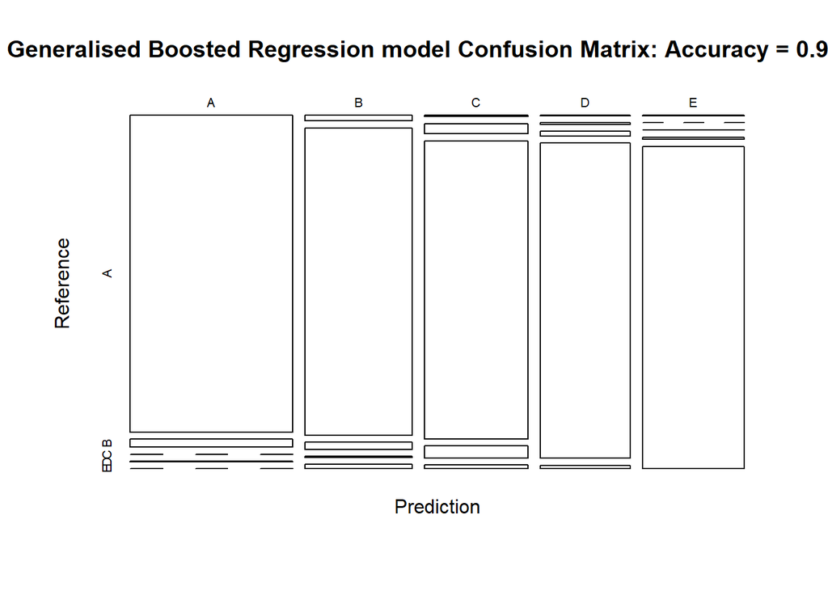

```r
plot(cmGBM$table, col = cmGBM$byClass, main = paste("Generalised Boosted Regression model Confusion Matrix: Accuracy =", round(cmGBM$overall['Accuracy'], 4)))
```

## Applying the best projection model

I will be using the prediction model to predict 20 different test cases. By comparing the accuracy rate values of the three models, it is clear the the ‘Random Forest’ model is the winner. So will use it on the validation data

# Preparing valid data

## Carry out the same transformation for the test data set

```r
testing<- testing[, NAColumns==F]
testing <- testing[, -NZV]
testing <- testing[, -c(1:6)]
dim(testing)
```

```
## [1] 20 53
```

```r
Results <- predict(modRF1, newdata=testing)
Results
```

```
##  [1] B A B A A E D B A A B C B A E E A B B B
## Levels: A B C D E
```